# Climate Report

Temperature and Precipitation 1960-2014

Alaa Amed

May 10, 2019

### Data

To produce this report, datasets from the University of Delaware about Air Temperature & Precipitation was used. for more information about the dataset click [here](https://www.esrl.noaa.gov/psd/data/gridded/data.UDel_AirT_Precip.html)

*Note: Only data from the month April for **1960, 1986, & 2014** is highlighed.*

### Temperature

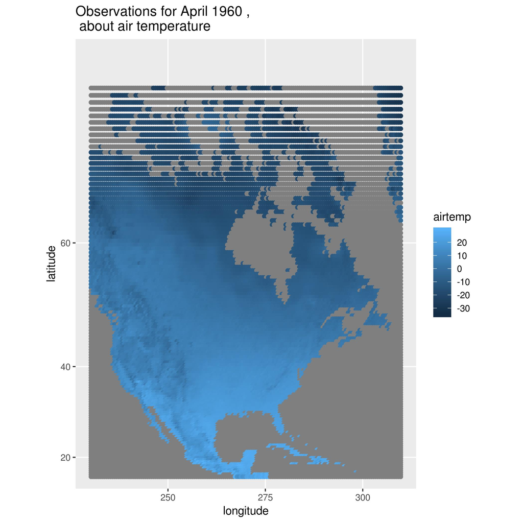

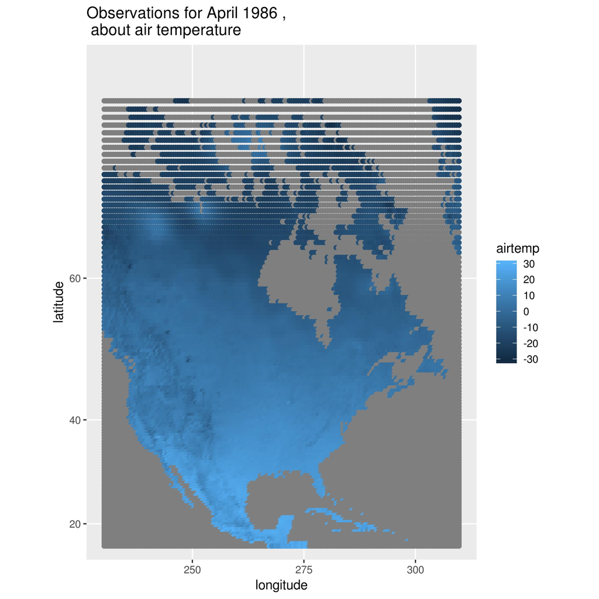

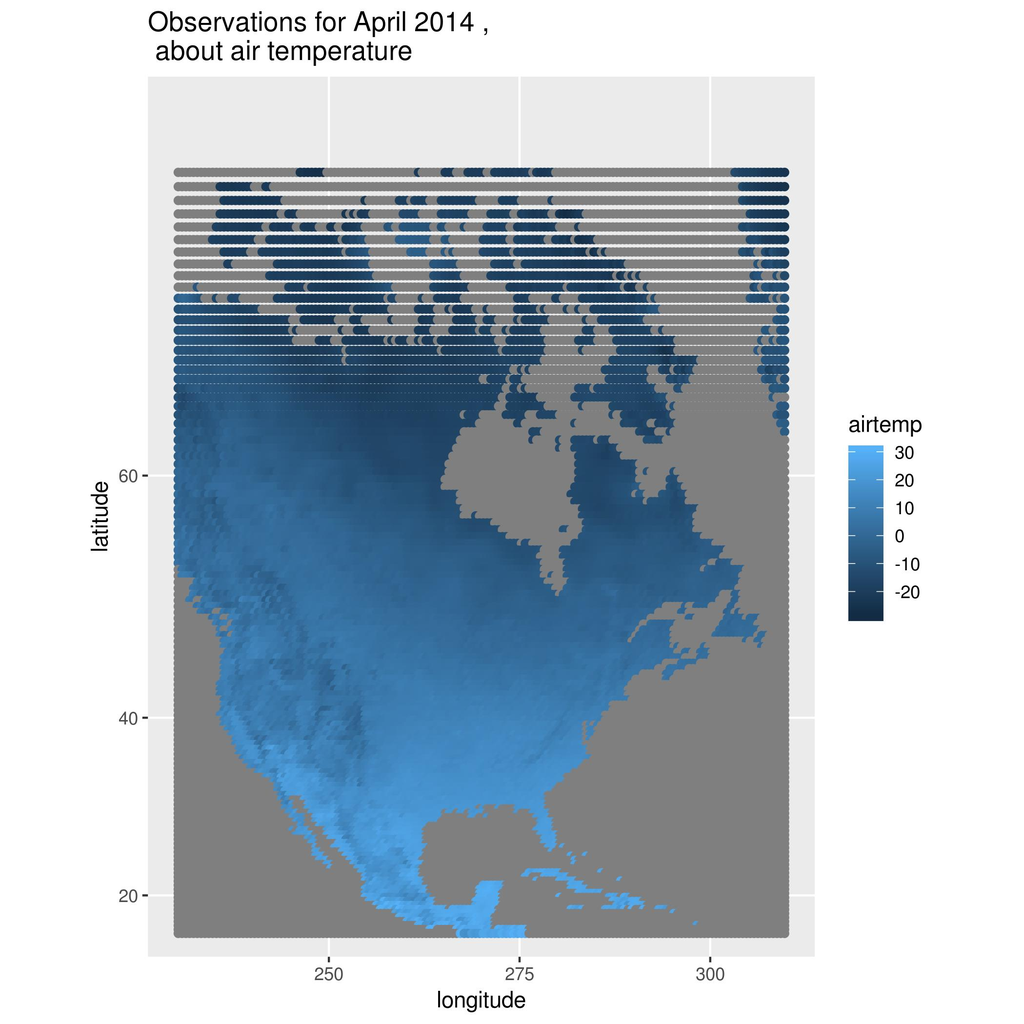

### Precipitation

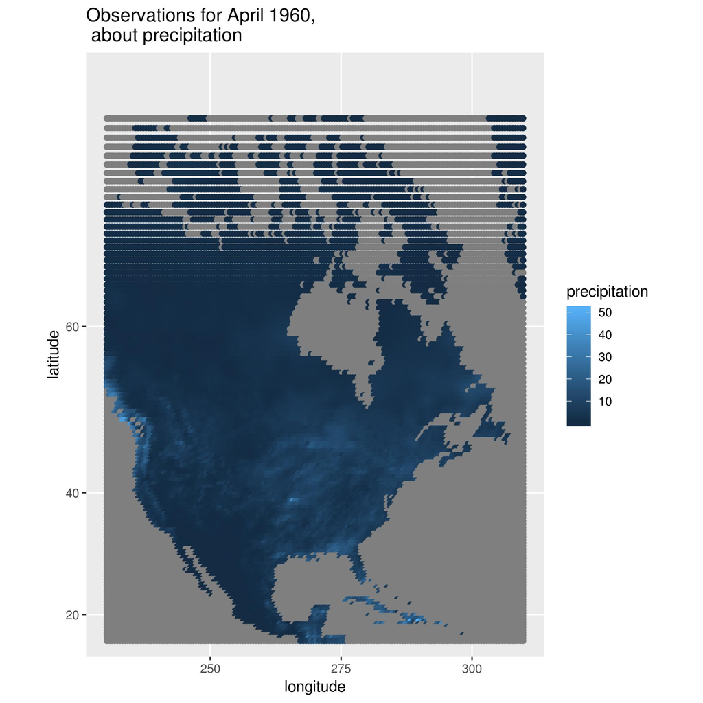

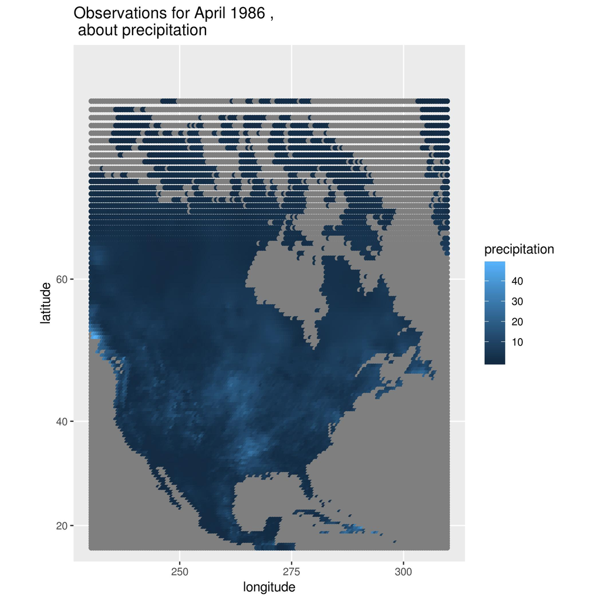

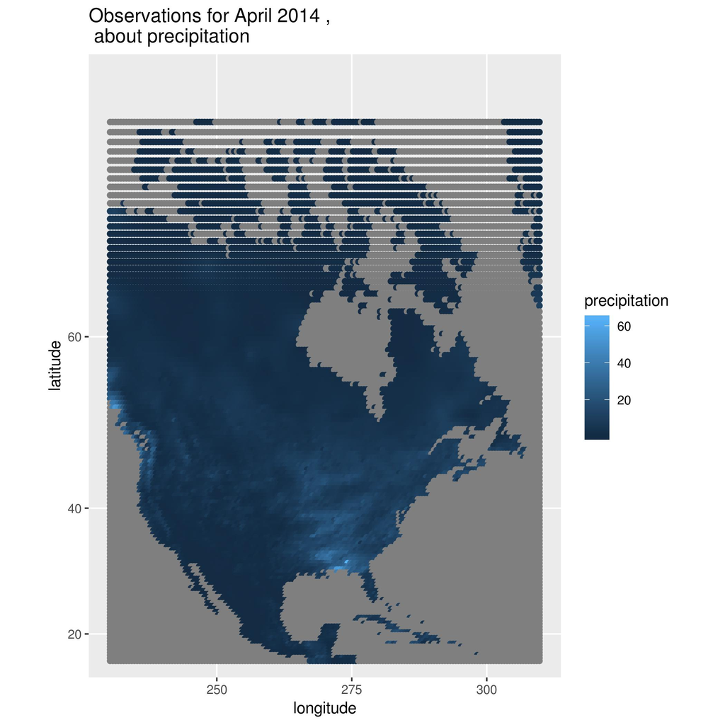

Overall, the three maps show a few changes in precipitation from 1960 to 2014. The main difference is a shift in heavy precipitation based on location. For instance, in 1986, we can see that the lower two thirds of the map has somewhat of an equal distribution of wet areas. Whereas in 2014, precipitation is mainly concentrated in the lower third (lat: 30-40, long: 260-280)

### Note:

you cannot do any conclusions about long-term trend based on just 3 figures. If you are interested, you are welcome to explore long-term trends in these data, but be sure to use more suitable methods.